# Simulating a single N-of-1 clinical trial

Ed Baskerville

4/25/2018

This file demonstrates how to run individual N-of-1 clinical trial simulations.

```r
source('../n1-simulator.R')
library(ggplot2)
```

The function `n1_simulate` is used to generate a time series:

```r
result <- n1_simulate(
  n_treatments = 2, n_blocks = 2,
  baseline_initial = 160,
  effect_size = c(-40, -30),
  tc_in = c(3, 2),
  tc_out = c(2, 3),
  tc_outcome = 1,
  sd_baseline = 0.4,
  sd_outcome = 0.6,
  sd_obs = 4.0,
  treatment_period = 30.0,
  sampling_timestep = 1.0,
  noise_timestep = 0.01,
  treatment_order = NULL,
  random_seed = 1,
  return_data_frame = TRUE
)
```

whose underlying and observed outcome can be viewed like so:

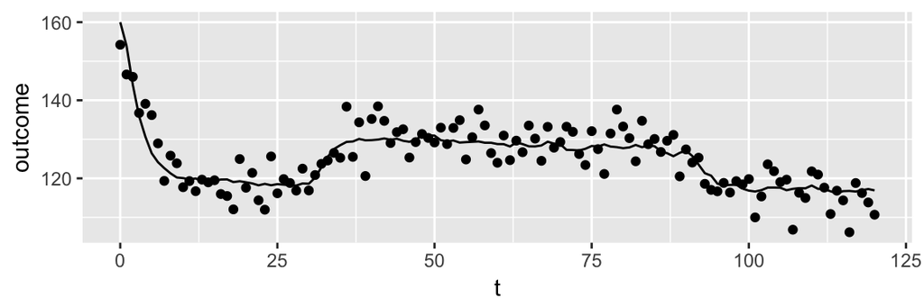

```r
ggplot(data = result$timeseries, aes(x = t)) + geom_line(aes(y = outcome)) + geom_point(aes(y = outcome_obs))
```

## Arguments and Return Values

`n1_simulate` takes model parameters, described in the next section, as well as: * `random_seed`, which will be generated randomly and returned if set to `NA` * `return_data_frame`, which determines whether the time series will be returned as a data frame (the default) or as a list of arrays, with multivariate components represented as multidimensional arrays rather than multiple columns.

All model parameters are required except `treatment_order`, which will be generated randomly if set to `NULL`.

`n1_simulate` returns a named list with three items:

- `random_seed`: the random seed used, which can be used to exactly reproduce the simulation.
- `treatment_order`: the treatment order used, as a matrix with `n_blocks` rows X `n_treatments` columns.
- `timeseries`: the time series data, either a data frame or a list of arrays depending on `return_data_frame`.

```r
result$random_seed
```

```
## [1] 1
```

```r
result$treatment_order
```

```
##      [,1] [,2]
## [1,]    1    2
## [2,]    2    1
```

## Model and Parameter Details

The study consists of `n_blocks` blocks, within which each of `n_treatments` treatments is applied. The total study duration will be `n_blocks * n_treatments * treatment_period`, or 120.

The baseline process, $B$ in the paper, is a discretized Wiener process starting at `baseline_initial`. The standard deviation of the amount of drift over 1 unit of time is equal to `sd_baseline`. The process is simulated at timesteps of `noise_timestep`.

For this simulation, the baseline process looks like so:

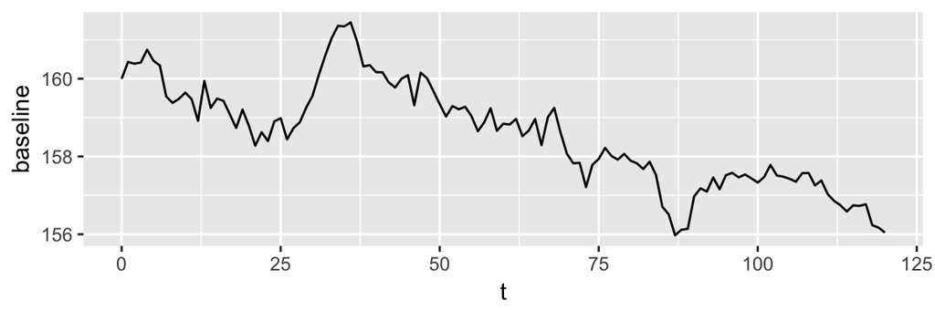

```r
ggplot(data = result$timeseries, aes(x = t, y = baseline)) + geom_line()
```

The effect process is a sum of effects from each treatment, each of which is modeled as exponential decays toward a target value. The run-in time constants are in `tc_in`; the wash-out time constants are in `tc_out`. The sum of all effects is stored in `timeseries$effect`:

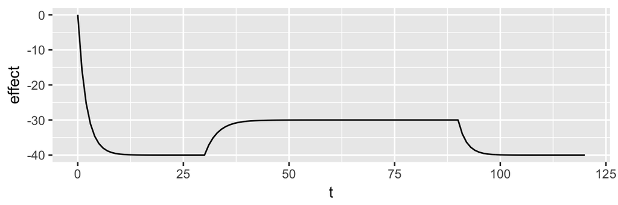

```r
ggplot(data = result$timeseries, aes(x = t, y = effect)) + geom_line()
```

The outcome process, $Z$ in the paper, is modeled as exponential decay toward `baseline + effect` with a time constant of `tc_outcome`, with decays and process noise occurring every `noise_timestep`.

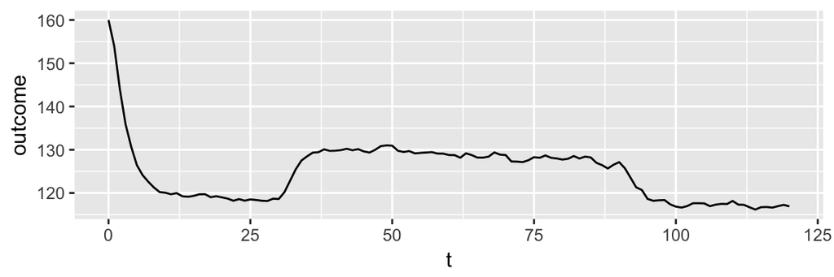

```r
ggplot(data = result$timeseries, aes(x = t, y = outcome)) + geom_line()
```

## Treatment Order

The treatment order can be provided as a parameter in one of three forms:

- A vector of length `n_treatments` containing an order to be repeated for every block
- A vector of length `n_blocks * n_treatments` containing the order across all blocks
- A matrix with `n_blocks` rows and `n_treatments` columns containing the treatment order for each block in the corresponding row.